# EasyVisa Project

#### Random Forest

```python
rf = RandomForestClassifier(random_state=1)
rf.fit(X_train,y_train)
```

```
RandomForestClassifier(random_state=1)
```

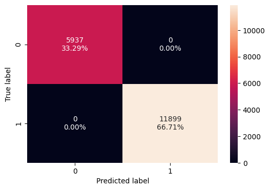

```python
confusion_matrix_sklearn(rf,X_train,y_train)
```

```python
rf_model_train_perf=model_performance_classification_sklearn(rf,X_train,y_train)
print("Training performance \n",rf_model_train_perf)
```

```
Training performance
    Accuracy  Recall  Precision   F1
0       1.0     1.0        1.0  1.0
```

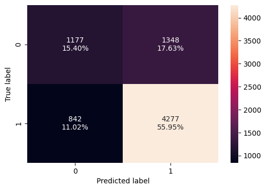

```python
confusion_matrix_sklearn(rf,X_test,y_test)
```

```python
rf_model_test_perf=model_performance_classification_sklearn(rf,X_test,y_test)
print("Testing performance \n",rf_model_test_perf)
```

```
Testing performance
    Accuracy    Recall  Precision        F1
0  0.713501  0.835515   0.760356  0.796165
```

- Random Forest has performed well in terms of accuracy and precision, but it is not able to generalize well on the test data in terms of F1 score. It is still performing better than the bagging model

**Random forest with class weights**

```python
rf_wt = RandomForestClassifier(class_weight={0:0.668,1:0.332}, random_state=1)
rf_wt.fit(X_train,y_train)
```

```
RandomForestClassifier(class_weight={0: 0.668, 1: 0.332}, random_state=1)
```

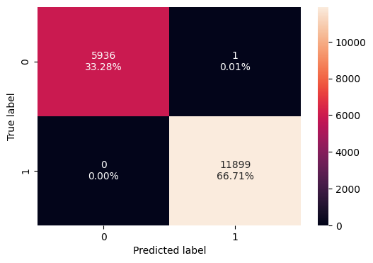

```python
confusion_matrix_sklearn(rf_wt, X_train,y_train)
```

```python
rf_wt_model_train_perf=model_performance_classification_sklearn(rf_wt, X_train,y_train)
print("Training performance \n",rf_wt_model_train_perf)
```

```
Training performance
    Accuracy  Recall  Precision        F1
0  0.999944     1.0   0.999916  0.999958
```

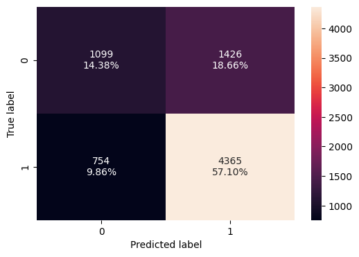

```python
confusion_matrix_sklearn(rf_wt, X_test,y_test)
```

```python
rf_wt_model_test_perf=model_performance_classification_sklearn(rf_wt, X_test,y_test)
print("Testing performance \n",rf_wt_model_test_perf)
```

```
Testing performance
    Accuracy    Recall  Precision        F1
0  0.714809  0.852706   0.753756  0.800183
```

Let's now look at Boosting models to see if these offer a better predictive ability.

### Boosting Models

Let us set up the classification models for prediction

#### AdaBoost Classifier

```python
from sklearn.ensemble import  GradientBoostingClassifier, AdaBoostClassifier, StackingClassifier
from xgboost import XGBClassifier
from sklearn import metrics
```

```python
ab_classifier=AdaBoostClassifier(random_state=1)
ab_classifier.fit(X_train,y_train)
```

```
AdaBoostClassifier(random_state=1)
```

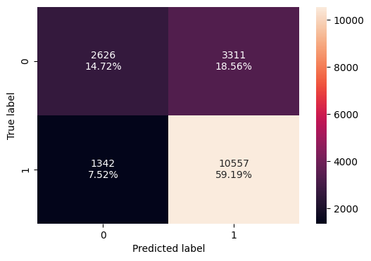

```python
confusion_matrix_sklearn(ab_classifier, X_train, y_train)
```

```python
ab_classifier_model_train_perf = model_performance_classification_sklearn(ab_classifier, X_train,y_train)
print("Training performance \n",ab_classifier_model_train_perf)
```

```
Training performance
    Accuracy    Recall  Precision       F1
0  0.739123  0.887217   0.761249  0.81942
```

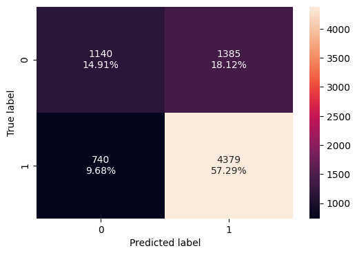

```python
confusion_matrix_sklearn(ab_classifier, X_test, y_test)
```

```python
ab_classifier_model_test_perf = model_performance_classification_sklearn(ab_classifier, X_test,y_test)
print("Testing performance \n",ab_classifier_model_test_perf)
```

```
Testing performance
    Accuracy    Recall  Precision        F1
0  0.722004  0.855441   0.759715  0.804741
```

- AdaBoost is generalizing well but it is giving poor performance. However, there are no signs of overfitting, as they both share a similar f1 score

#### Gradient Boosting Classifier

```python
gb_estimator=GradientBoostingClassifier(random_state=1)
gb_estimator.fit(X_train,y_train)
```

```
GradientBoostingClassifier(random_state=1)
```

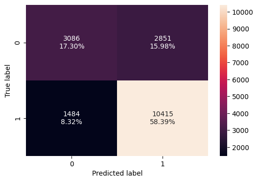

```python
confusion_matrix_sklearn(gb_estimator, X_train, y_train)
```

```python
gb_estimator_model_train_perf = model_performance_classification_sklearn(gb_estimator, X_train,y_train)
print("Training performance \n",gb_estimator_model_train_perf)
```

```
Training performance
    Accuracy    Recall  Precision        F1
0  0.756952  0.875284    0.78509  0.827737
```

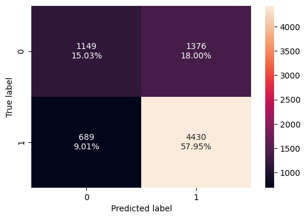

```python
confusion_matrix_sklearn(gb_estimator, X_test, y_test)
```

```python
gb_estimator_model_test_perf = model_performance_classification_sklearn(gb_estimator, X_test, y_test)
print("Testing performance \n",gb_estimator_model_test_perf)
```

```
Testing performance
    Accuracy    Recall  Precision        F1
0  0.729853  0.865403   0.763004  0.810984
```

- Gradient boosting is generalizing well and giving improved results over AdaBoost Classifier. Let's see if XGBoost offers a better performance

#### XGBoost Classifier

```python
xgb_estimator=XGBClassifier(random_state=1, verbosity = 0)
xgb_estimator.fit(X_train,y_train)
```

```
XGBClassifier(base_score=None, booster=None, callbacks=None,
              colsample_bylevel=None, colsample_bynode=None,
              colsample_bytree=None, device=None, early_stopping_rounds=None,
              enable_categorical=False, eval_metric=None, feature_types=None,
              gamma=None, grow_policy=None, importance_type=None,
              interaction_constraints=None, learning_rate=None, max_bin=None,
              max_cat_threshold=None, max_cat_to_onehot=None,
              max_delta_step=None, max_depth=None, max_leaves=None,
              min_child_weight=None, missing=nan, monotone_constraints=None,
              multi_strategy=None, n_estimators=None, n_jobs=None,
              num_parallel_tree=None, random_state=1, ...)
```

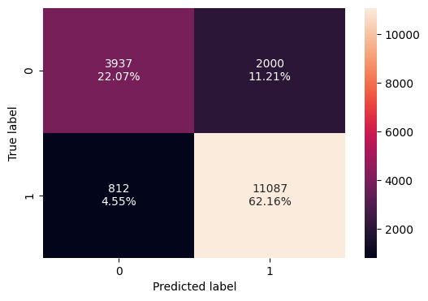

```python
confusion_matrix_sklearn(xgb_estimator, X_train, y_train)
```

```python
xgb_estimator_model_train_perf = model_performance_classification_sklearn(xgb_estimator, X_train, y_train)
print("Training performance \n",xgb_estimator_model_train_perf)
```

```
Training performance
    Accuracy    Recall  Precision        F1
0  0.842341  0.931759   0.847177  0.887457
```

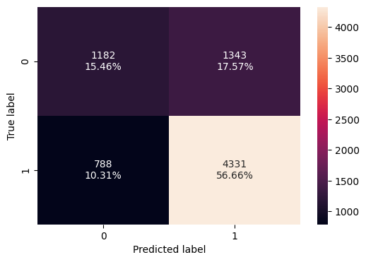

```python
confusion_matrix_sklearn(xgb_estimator, X_test, y_test)
```

```python
xgb_estimator_model_test_perf = model_performance_classification_sklearn(xgb_estimator, X_test,y_test)
print("Testing performance \n",xgb_estimator_model_test_perf)
```

```
Testing performance
    Accuracy    Recall  Precision        F1
0  0.721219  0.846064   0.763306  0.802557
```

- XGBoost with default parameters is giving a good performance for the train dataset but not for the test dataset. Now let's look at tuning the hyperparameters to see if this will yield greater performance improvement.

### Model Tuning

Let us first start with tuning a decision tree.

#### Decision Tree tuned

```python
# Choose the type of classifier.
dtree_estimator = DecisionTreeClassifier(class_weight=class_weight_y,random_state=1)

# Grid of parameters to choose from
param_grid = {
    'max_depth': np.arange(2,6),
    'min_samples_leaf': [1, 4, 7],
    'max_leaf_nodes' : [10, 15],
    'min_impurity_decrease': [0.0001,0.001]
}

# Type of scoring used to compare parameter combinations
f1_scorer = metrics.make_scorer(metrics.f1_score)

# Run the grid search
grid_obj = GridSearchCV(dtree_estimator, param_grid, scoring=f1_scorer)
grid_obj = grid_obj.fit(X_train, y_train)

# Set the clf to the best combination of parameters
dtree_estimator = grid_obj.best_estimator_

# Fit the best algorithm to the data.
dtree_estimator.fit(X_train, y_train)
```

```
DecisionTreeClassifier(class_weight={0: 0.668, 1: 0.332}, max_depth=5,
                       max_leaf_nodes=15, min_impurity_decrease=0.0001,
                       random_state=1)
```

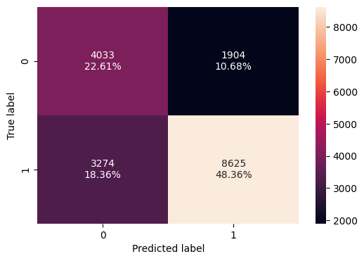

```python
confusion_matrix_sklearn(dtree_estimator, X_train,y_train)
```

```python
dtree_model_train_perf_tuned =model_performance_classification_sklearn(dtree_estimator, X_train, y_train)
print("Training performance \n",dtree_model_train_perf_tuned)
```

```
Training performance
    Accuracy    Recall  Precision        F1
0  0.709688  0.724851   0.819166  0.769128
```

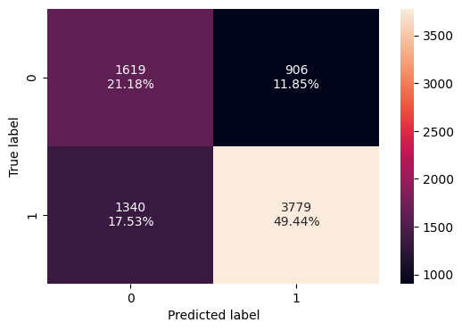

```python
confusion_matrix_sklearn(dtree_estimator, X_test,y_test)
```

```python
dtree_model_test_perf_tuned =model_performance_classification_sklearn(dtree_estimator, X_test,y_test)
print("Training performance \n",dtree_model_test_perf_tuned)
```

```
Training performance
    Accuracy   Recall  Precision       F1
0  0.706175  0.73823   0.806617  0.77091
```

Decision trees although yielding worse performance for train and test, appear to not overfit the data

#### Bagging Tuned

```python
# grid search for bagging classifier
cl1 = DecisionTreeClassifier(class_weight=class_weight_y,random_state=1)

# Grid of parameters to choose from
param_grid = {
    'max_samples': [0.8,0.9,1],
    'max_features': [0.7,0.8,0.9],
    'n_estimators' : [30,50,70],
}
grid = GridSearchCV(BaggingClassifier(random_state=1,bootstrap=True), param_grid=param_grid, scoring = f1_scorer, cv=5, n_jobs=-1)
grid.fit(X_train, y_train)

## getting the best estimator
bagging_estimator_tuned  = grid.best_estimator_
bagging_estimator_tuned.fit(X_train,y_train)
```

```
BaggingClassifier(max_features=0.7, max_samples=0.9, n_estimators=70,
                  random_state=1)
```

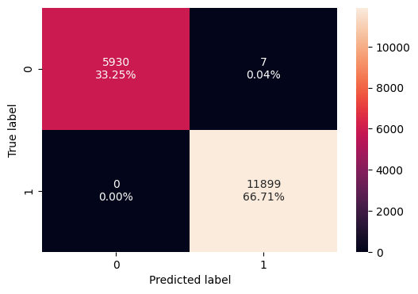

```python
confusion_matrix_sklearn(bagging_estimator_tuned, X_train,y_train)
```

```python
bagging_model_train_perf_tuned =model_performance_classification_sklearn(bagging_estimator_tuned, X_train, y_train)
print("Training performance \n",bagging_model_train_perf_tuned)
```

```
Training performance
    Accuracy  Recall  Precision        F1
0  0.999608     1.0   0.999412  0.999706
```

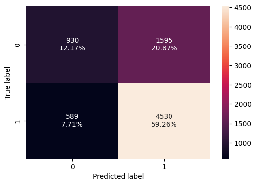

```python
confusion_matrix_sklearn(bagging_estimator_tuned, X_test,y_test)
```

```python
bagging_model_test_perf_tuned = model_performance_classification_sklearn(bagging_estimator_tuned, X_test,y_test)
print("Training performance \n",bagging_model_test_perf_tuned)
```

```
Training performance
    Accuracy    Recall  Precision        F1
0  0.714286  0.884938   0.739592  0.805763
```

#### Random Forest Tuned

```python
# Choose the type of classifier.
rf_estimator = RandomForestClassifier(random_state=1)

# Grid of parameters to choose from
param_grid = {
    "n_estimators": [50,110,25],
    "min_samples_leaf": np.arange(1, 4),
    "max_features": [np.arange(0.3, 0.6, 0.1),'sqrt'],
    "max_samples": np.arange(0.4, 0.7, 0.1)
}
# Run the grid search
grid_obj = GridSearchCV(rf_estimator, param_grid, scoring=f1_scorer,cv=5)
grid_obj = grid_obj.fit(X_train, y_train)

# Set the clf to the best combination of parameters
rf_estimator = grid_obj.best_estimator_

# Fit the best algorithm to the data.
rf_estimator.fit(X_train, y_train)
```

```
RandomForestClassifier(max_samples=0.4, min_samples_leaf=3, n_estimators=110,
                       random_state=1)
```

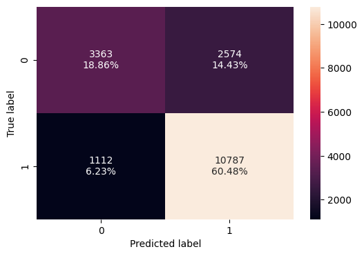

```python
confusion_matrix_sklearn(rf_estimator, X_train,y_train)
```

```python
rf_tuned_model_train_perf_tuned =model_performance_classification_sklearn(rf_estimator, X_train, y_train)
print("Training performance \n",rf_tuned_model_train_perf_tuned)
```

```
Training performance
    Accuracy    Recall  Precision        F1
0  0.793339  0.906547    0.80735  0.854078
```

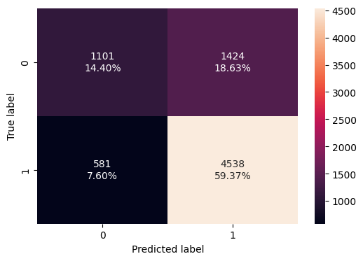

```python
confusion_matrix_sklearn(rf_estimator, X_test,y_test)
```

```python
rf_tuned_model_test_perf_tuned = model_performance_classification_sklearn(rf_estimator, X_test,y_test)
print("Training performance \n",rf_tuned_model_test_perf_tuned)
```

```
Training performance
    Accuracy    Recall  Precision       F1
0  0.737703  0.886501   0.761154  0.81906
```

#### AdaBoost Tuned

```python
# Choose the type of classifier.
ab_tuned = AdaBoostClassifier(random_state=1)

# Grid of parameters to choose from
param_grid = {
    "n_estimators": np.arange(50,110,25),
    "learning_rate": [0.01,0.1,0.05],
    "base_estimator": [
        DecisionTreeClassifier(max_depth=2, random_state=1),
        DecisionTreeClassifier(max_depth=3, random_state=1),
    ],
}
# Run the grid search
grid_obj = GridSearchCV(ab_tuned, param_grid, scoring=f1_scorer,cv=5, n_jobs = -1)
grid_obj = grid_obj.fit(X_train, y_train)

# Set the clf to the best combination of parameters
ab_tuned = grid_obj.best_estimator_

# Fit the best algorithm to the data.
ab_tuned.fit(X_train, y_train)
```

```
AdaBoostClassifier(base_estimator=DecisionTreeClassifier(max_depth=3,
                                                         random_state=1),
                   learning_rate=0.1, random_state=1)
```

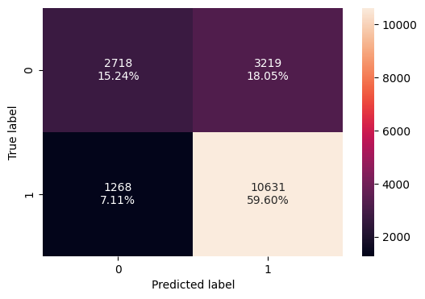

```python
confusion_matrix_sklearn(ab_tuned, X_train,y_train)
```

```python
ab_tuned_model_train_perf_tuned =model_performance_classification_sklearn(ab_tuned, X_train, y_train)
print("Training performance \n",ab_tuned_model_train_perf_tuned)
```

```
Training performance
    Accuracy    Recall  Precision        F1
0   0.74843  0.893436   0.767581  0.825741
```

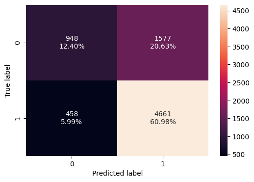

```python
confusion_matrix_sklearn(ab_tuned, X_test,y_test)
```

```python
ab_tuned_model_test_perf_tuned = model_performance_classification_sklearn(ab_tuned, X_test,y_test)
print("Training performance \n",ab_tuned_model_test_perf_tuned)
```

```
Training performance
    Accuracy    Recall  Precision        F1
0  0.733778  0.910529   0.747195  0.820815
```

#### Gradient Boosting Tuned

```python
# Choose the type of classifier.
gb_tuned = GradientBoostingClassifier(random_state=1)

# Grid of parameters to choose from
param_grid = {
    "init": [AdaBoostClassifier(random_state=1),DecisionTreeClassifier(random_state=1)],
    "n_estimators": np.arange(50,110,25),
    "learning_rate": [0.01,0.1,0.05],
    "subsample":[0.7,0.9],
    "max_features":[0.5,0.7,1],
}

# Run the grid search
grid_obj = GridSearchCV(gb_tuned, param_grid, scoring=f1_scorer,cv=5,n_jobs = -1)
grid_obj = grid_obj.fit(X_train, y_train)

# Set the clf to the best combination of parameters
gb_tuned = grid_obj.best_estimator_

# Fit the best algorithm to the data.
gb_tuned.fit(X_train, y_train)
```

```
GradientBoostingClassifier(init=AdaBoostClassifier(random_state=1),
                           max_features=0.7, n_estimators=50, random_state=1,
                           subsample=0.9)
```

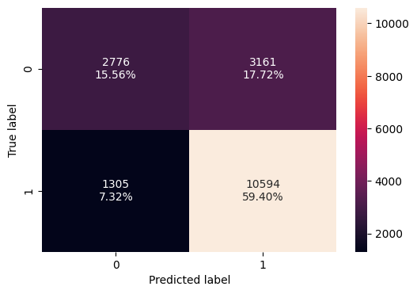

```python
confusion_matrix_sklearn(gb_tuned, X_train,y_train)
```

```python
gb_tuned_model_train_perf_tuned =model_performance_classification_sklearn(gb_tuned, X_train, y_train)
print("Training performance \n",gb_tuned_model_train_perf_tuned)
```

```
Training performance
    Accuracy    Recall  Precision        F1
0  0.749608  0.890327   0.770193  0.825914
```

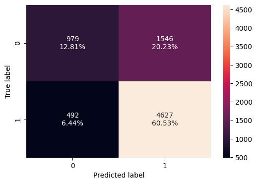

```python
confusion_matrix_sklearn(gb_tuned, X_test,y_test)
```

```python
gb_tuned_model_test_perf_tuned = model_performance_classification_sklearn(gb_tuned, X_test,y_test)
print("Training performance \n",gb_tuned_model_test_perf_tuned)
```

```
Training performance
    Accuracy    Recall  Precision        F1
0  0.733386  0.903887   0.749555  0.819518
```

#### XG Boosting Tuned

```python
# Choose the type of classifier.
xgb_tuned = XGBClassifier(random_state=1, verbosity = 0)

# Grid of parameters to choose from
param_grid={'n_estimators':np.arange(50,110,25),
            'scale_pos_weight':[1,2,5],
            'learning_rate':[0.01,0.1,0.05],
            'gamma':[1,3],
            'subsample':[0.7,0.9]
}

# Run the grid search
grid_obj = GridSearchCV(xgb_tuned, param_grid, scoring=f1_scorer,cv=5, n_jobs=-1)
grid_obj = grid_obj.fit(X_train, y_train)

# Set the clf to the best combination of parameters
xgb_tuned = grid_obj.best_estimator_

# Fit the best algorithm to the data.
xgb_tuned.fit(X_train, y_train)
```

```
XGBClassifier(base_score=None, booster=None, callbacks=None,
              colsample_bylevel=None, colsample_bynode=None,
              colsample_bytree=None, device=None, early_stopping_rounds=None,
              enable_categorical=False, eval_metric=None, feature_types=None,
              gamma=1, grow_policy=None, importance_type=None,
              interaction_constraints=None, learning_rate=0.05, max_bin=None,
              max_cat_threshold=None, max_cat_to_onehot=None,
              max_delta_step=None, max_depth=None, max_leaves=None,
              min_child_weight=None, missing=nan, monotone_constraints=None,
              multi_strategy=None, n_estimators=50, n_jobs=None,
              num_parallel_tree=None, random_state=1, ...)
```

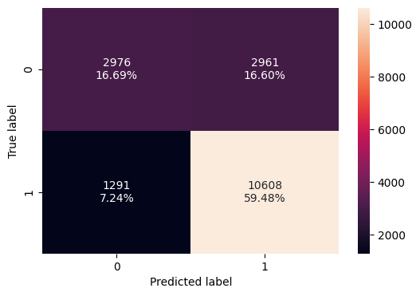

```python
confusion_matrix_sklearn(xgb_tuned, X_train,y_train)
```

```python
xgb_tuned_model_train_perf_tuned =model_performance_classification_sklearn(xgb_tuned, X_train, y_train)
print("Training performance \n",xgb_tuned_model_train_perf_tuned)
```

```
Training performance
    Accuracy    Recall  Precision        F1
0  0.761606  0.891503   0.781782  0.833045
```

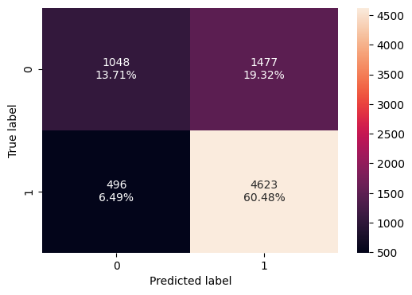

```python
confusion_matrix_sklearn(xgb_tuned, X_test,y_test)
```

```python
xgb_tuned_model_test_perf_tuned = model_performance_classification_sklearn(xgb_tuned, X_test,y_test)
print("Training performance \n",xgb_tuned_model_test_perf_tuned)
```

```
Training performance
    Accuracy    Recall  Precision        F1
0  0.741889  0.903106   0.757869  0.824138
```

#### Stacking Model

**Now, let's build a stacking model with the tuned models - decision tree, random forest, and gradient boosting, then use XGBoost to get the final prediction.**

```python
estimators=[('Decision Tree', dtree_estimator),('Random Forest', rf_estimator),
           ('Gradient Boosting', gb_tuned)]
final_estimator=XGBClassifier(random_state=1, verbosity = 0)
```

```python
stacking_estimator=StackingClassifier(estimators=estimators, final_estimator=final_estimator,cv=5,n_jobs=-1)
stacking_estimator.fit(X_train,y_train)
```

```
StackingClassifier(cv=5,
                   estimators=[('Decision Tree',
                                DecisionTreeClassifier(class_weight={0: 0.668,
                                                                     1: 0.332},
                                                       max_depth=5,
                                                       max_leaf_nodes=15,
                                                       min_impurity_decrease=0.0001,
                                                       random_state=1)),
                               ('Random Forest',
                                RandomForestClassifier(max_samples=0.4,
                                                       min_samples_leaf=3,
                                                       n_estimators=110,
                                                       random_state=1)),
                               ('Gradient Boosting',
                                GradientBoostingClassifier(init=AdaBoost...
                                                 grow_policy=None,
                                                 importance_type=None,
                                                 interaction_constraints=None,
                                                 learning_rate=None,
                                                 max_bin=None,
                                                 max_cat_threshold=None,
                                                 max_cat_to_onehot=None,
                                                 max_delta_step=None,
                                                 max_depth=None,
                                                 max_leaves=None,
                                                 min_child_weight=None,
                                                 missing=nan,
                                                 monotone_constraints=None,
                                                 multi_strategy=None,
                                                 n_estimators=None, n_jobs=None,
                                                 num_parallel_tree=None,
                                                 random_state=1, ...),
                   n_jobs=-1)
```

```python
stacking_estimator_model_train_perf = model_performance_classification_sklearn(stacking_estimator, X_train, y_train)
print("Training performance \n",stacking_estimator_model_train_perf)
```

```
Training performance
    Accuracy   Recall  Precision        F1
0  0.754149  0.87562   0.781972  0.826151
```

```python
stacking_estimator_model_test_perf = model_performance_classification_sklearn(stacking_estimator, X_test, y_test)
print("Testing performance \n",stacking_estimator_model_test_perf)
```

```
Testing performance
    Accuracy    Recall  Precision        F1
0  0.733647  0.878492   0.760785  0.815413
```

## Model Performance Comparison and Conclusions

```python
# training performance comparison

models_train_comp_df = pd.concat(
    [dtree_model_train_perf.T, dtree_model_train_perf_tuned.T, rf_model_train_perf.T,rf_tuned_model_train_perf_tuned.T,
    ab_classifier_model_train_perf.T,ab_tuned_model_train_perf_tuned.T,gb_estimator_model_train_perf.T,gb_tuned_model_train_perf_tuned.T,
    xgb_estimator_model_train_perf.T,xgb_tuned_model_train_perf_tuned.T,stacking_estimator_model_train_perf.T],
    axis=1,
)

models_train_comp_df.columns = [
    "Decision Tree",
    "Decision Tree Tuned",
    "Random Forest Estimator",
    "Random Forest Tuned",
    "Adaboost Regressor",
    "Adaboost Tuned",
    "Gradient Boost Estimator",
    "Gradient Boost Tuned",
    "XGB",
    "XGB Tuned",
    "Stacking Classifier"
]

print("Training performance comparison:")
models_train_comp_df
```

```
Training performance comparison:
```

|  | Decision Tree | Decision Tree Tuned | Random Forest Estimator | Random Forest Tuned | Adaboost Regressor | Adaboost Tuned | Gradient Boost Estimator | Gradient Boost Tuned | XGB | XGB Tuned | Stacking Classifier |
| --- | --- | --- | --- | --- | --- | --- | --- | --- | --- | --- | --- |
| Accuracy | 1.0 | 0.709688 | 1.0 | 0.793339 | 0.739123 | 0.748430 | 0.756952 | 0.749608 | 0.842341 | 0.761606 | 0.754149 |
| Recall | 1.0 | 0.724851 | 1.0 | 0.906547 | 0.887217 | 0.893436 | 0.875284 | 0.890327 | 0.931759 | 0.891503 | 0.875620 |
| Precision | 1.0 | 0.819166 | 1.0 | 0.807350 | 0.761249 | 0.767581 | 0.785090 | 0.770193 | 0.847177 | 0.781782 | 0.781972 |
| F1 | 1.0 | 0.769128 | 1.0 | 0.854078 | 0.819420 | 0.825741 | 0.827737 | 0.825914 | 0.887457 | 0.833045 | 0.826151 |

```python
# test performance comparison

models_test_comp_df = pd.concat(
    [dtree_model_test_perf.T, dtree_model_test_perf_tuned.T, rf_model_test_perf.T,rf_tuned_model_test_perf_tuned.T,
    ab_classifier_model_test_perf.T,ab_tuned_model_test_perf_tuned.T,gb_estimator_model_test_perf.T,gb_tuned_model_test_perf_tuned.T,
    xgb_estimator_model_test_perf.T,xgb_tuned_model_test_perf_tuned.T,stacking_estimator_model_test_perf.T],
    axis=1,
)

models_test_comp_df.columns = [
    "Decision Tree",
    "Decision Tree Tuned",
    "Random Forest Estimator",
    "Random Forest Tuned",
    "Adaboost Regressor",
    "Adaboost Tuned",
    "Gradient Boost Estimator",
    "Gradient Boost Tuned",
    "XGB",
    "XGB Tuned",
    "Stacking Classifier"
]

print("Test performance comparison:")
models_test_comp_df
```

```
Test performance comparison:
```

|  | Decision Tree | Decision Tree Tuned | Random Forest Estimator | Random Forest Tuned | Adaboost Regressor | Adaboost Tuned | Gradient Boost Estimator | Gradient Boost Tuned | XGB | XGB Tuned | Stacking Classifier |
| --- | --- | --- | --- | --- | --- | --- | --- | --- | --- | --- | --- |
| Accuracy | 0.658032 | 0.706175 | 0.713501 | 0.737703 | 0.722004 | 0.733778 | 0.729853 | 0.733386 | 0.721219 | 0.741889 | 0.733647 |
| Recall | 0.748974 | 0.738230 | 0.835515 | 0.886501 | 0.855441 | 0.910529 | 0.865403 | 0.903887 | 0.846064 | 0.903106 | 0.878492 |
| Precision | 0.742592 | 0.806617 | 0.760356 | 0.761154 | 0.759715 | 0.747195 | 0.763004 | 0.749555 | 0.763306 | 0.757869 | 0.760785 |
| F1 | 0.745769 | 0.770910 | 0.796165 | 0.819060 | 0.804741 | 0.820815 | 0.810984 | 0.819518 | 0.802557 | 0.824138 | 0.815413 |

#### Feature importance by model

#### XG Boost Tuned Feature Importance

```python
# importance of features in the tree building ( The importance of a feature is computed as the
#(normalized) total reduction of the criterion brought by that feature. It is also known as the Gini importance )

print (pd.DataFrame(xgb_tuned.feature_importances_, columns = ["Imp"], index = X_train.columns).sort_values(by = 'Imp', ascending = False))
```

```
                                        Imp
education_of_employee_High School  0.389856
has_job_experience_Y               0.108824
unit_of_wage_Year                  0.078497
continent_Europe                   0.067865
education_of_employee_Master's     0.056782
education_of_employee_Doctorate    0.055120
region_of_employment_Midwest       0.035429
region_of_employment_South         0.030698
region_of_employment_West          0.021370
continent_North America            0.019304
prevailing_wage                    0.018897
full_time_position_Y               0.017099
continent_Asia                     0.016431
continent_South America            0.015553
region_of_employment_Northeast     0.013194
requires_job_training_Y            0.012565
continent_Oceania                  0.011842
no_of_employees                    0.008015
company_age                        0.007901
unit_of_wage_Week                  0.007600
unit_of_wage_Month                 0.007160
```

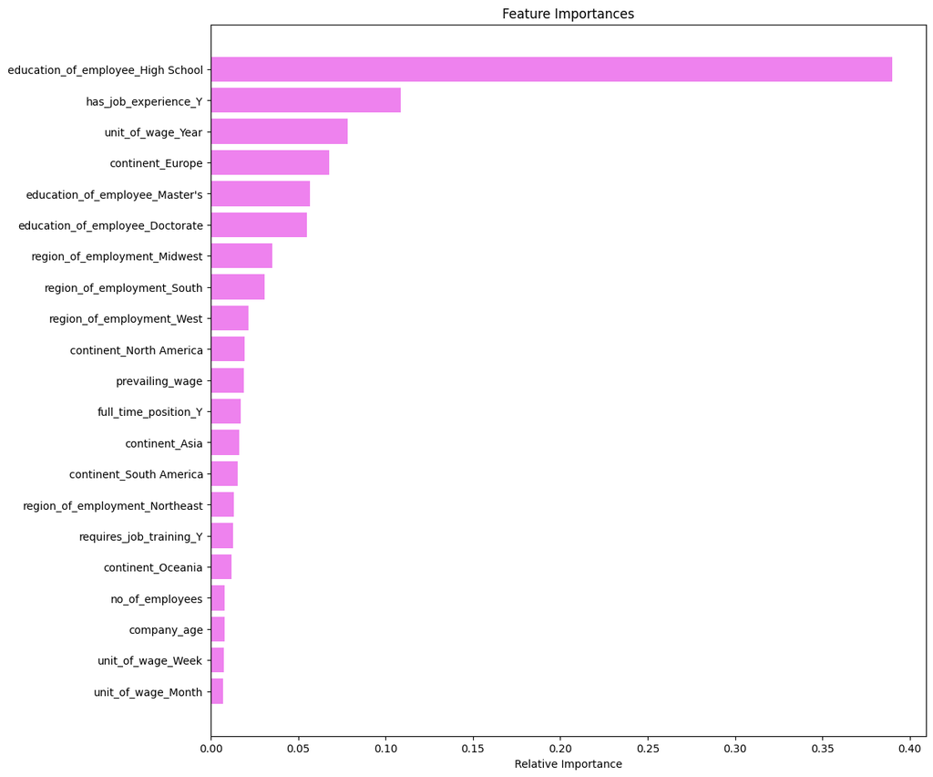

```python
feature_names = X_train.columns

importances = xgb_tuned.feature_importances_
indices = np.argsort(importances)

plt.figure(figsize=(12,12))
plt.title('Feature Importances')
plt.barh(range(len(indices)), importances[indices], color='violet', align='center')
plt.yticks(range(len(indices)), [feature_names[i] for i in indices])
plt.xlabel('Relative Importance')
plt.show()
```

## Actionable Insights and Recommendations

Overall, I have created a classification model utilizing ensemble techniques to predict the likelihood of whether a visa applicant would be accepted and rejected.

From this situation, I was able to compare several models and have decided to utilize the tuned XG Boosting tuned model. The reason for this is because it does not appear to show overfitting nor underfitting, in addition to having the highest F1 performance on the test dataset.

Tuning the models improves their overall data prediction capacity

With this in mind, there are several interesting insights that follow:

- We have been able to build a predictive model: a) that we can employ to identify candidates that will likely be accepted or rejected from their visa application. b) the main drivers for visa application acceptance c) based on these factors, applicants can make sure they have these in place before applying to increase visa application likelihood.
- Factors that drive visa acceptance - Having a high school degree, having job experience, and having a job with a yearly wage.
- Having a high school degree: It's important to note that high school education is the most important feature. However, we also notice that having a master's or doctorate degree is also highly important. Not surprising, I could argue that education is one of the most important features. As the level of education increases, we see an increased likelihood of being certified for one's visa.
- Job Experience: Applicants with work experience are more likely to be certified for their visa. After all, coming to work into a different country, it's more likely to get accepted for a visa if you already bring something to the table for work other than education.
- Yearly wage: Although the majority of jobs are labeled as yearly, it's important to note that applicants coming into the country will more likely be accepted because yearly jobs tend to be full-time. This gives the customs officer more confidence that one won't be out of work unlike hourly or contract jobs which operate with more flexibility.
- Europe: Finally, it appears that visa applicants from Europe have a high er likelyhood of having their visa accepted. Although one could argue that people from that contient may have a higher education certifications compared ot other contients.
- It is interesting to note that the prevailing wage does not have a big impact when it comes to visa certification. One would think that higher paid jobs might improve one's chance of a visa, but this doesn't show to be the case.
- Overall, our model is limited by the data we currently have. It'll be important to continue the data collection system and rerun the model to make it more robust and look for additional metrics to measure. For example, the type of visa, duration of visa or whether it's a renewal or first visa.